# Rapport - Valeurs Extrêmes

Alexis Guyonvarch - Philippe Real

17 janvier, 2020

Abstract

# Introduction

## Rappel des notions fondamentales de la théorie des valeurs extrêmes

On étudie un n-échantillon iid de v.a $X_1,X_2,....,X_n$ de même loi, de fonction de répartition F, et on considère la v.a $X_{n,n}=max(X_1,X_2,....,X_n)$ dont on cherche à décrire statistiquement le comportement asymptotique.

Par la propriété d’indépendance de l’échantillon, la fonction de répartition la loi du max $X_{n,n}$ peut s’écrire aussi $F^n$.

### Domaine d’attraction et théorème des valeurs extrêmes

La théorie des valeurs extrêmes s’appuie sur la notion de “Domaine Maximum d’attraction” MDA(G) où $G$ est la fonction de répartition d’une v.a non dégénérée (i.e associée à une va non constante) limite en loi (?) de la suite “rescalée?” $X_{n,n}^*=\frac{X_{n,n}-b_n}{a_n}$.

Plus précisemment, on dit que F appartient au domaine d’attraction DMA(G) de G ssi il existe deux suites $a_n$>0 et $b_n$ telles que : $\displaystyle \lim_{n \to +\infty} F^n(a_nx+b_n)=G(x)$ $\forall x \in \mathbb{R}$ De manière équivalent : $X_{n,n}^*\xrightarrow{d} Y$ où $Y$ est une loi ayant pour fonction de répartition $G$.

Le domaine d’attraction est unique pour les paramètre de position et de dimensionnement (scale) fixés.

Le théorème des valeurs extrêmes stipule qu’il n’y a que 3 grandes familles (ou ensemble) de domaines d’attractions ou dit autrement 3 grandes familles de fonctions de répartitions limites pour $X_{n,n}^*$. Qui sont les familles de Gumbel, Frêchet et Weibull. Ces familles de lois des extrêmes ont des profiles et des comportement asymptotique différents.

Si la loi limite $F \in MDA(G)$ alors la lois de répartition G est de l’une des formes suivantes :

- Fréchet: définit pour $\gamma >0$ par $\phi^{F}(x)=exp(-\frac{(x-b)}{a})^{-1/\gamma}$ si x > b et 0 sinon.
- Weibull: définit pour $\gamma >0$ par $\phi^{W}(x)=exp(\frac{(x-b)}{a})^{1/\gamma}$ si x < b et 1 sinon.
- Gumbel: définit par $\phi^{G}(x)=exp(-exp(-\frac{(x-b)}{a}))$ si x $\in \mathbb{R}$.

### GEV (General Extreme Distribution)

On peut reformuler ce théorème et obtenir une forme unique pour G, la distibution générale des valeurs extrêmes ou GEV, c’est le théorème de Fisher-Tippett-Gnedenko, qui peut être vu comme un équivalent du CLT pour les valeurs extrêmes :

Si il existe deux suites normalisantes $(a_n)_{n \geq 1}$>0 et $(b_n)_{n \geq 1} \in \mathbb{R}$ ainsi qu’une distribution non dégénérée $H$ telles que :

$\displaystyle\lim_{n \to +\infty} P(\frac{X_{n,n}-b_n}{a_n} \leq \gamma)=\displaystyle\lim_{n \to +\infty} F^n(a_nx+b_n)=H(x)$

Alors $H$ est de la forme suivante :

- $H_{\gamma,a,b}(x)=exp\{-[1+\gamma(\frac{x-b}{a})]^{-1/\gamma}\}$ et définit sur l’ensemble $\{x:1+\gamma \frac{x-b}{a} >0 \}$ où $-\infty <b<+\infty,$ $a>0$ et $\gamma \in \mathbb{R}$

Si F vérifie ce théorème, on dit alors que F appartient au domaine d’attraction de$H_{\gamma,a,b}$

En se basant sur le signe de $\gamma$ on distingue les trois domaines d’attraction:

- Si $\gamma<0$ $F$ est dit appartenir au domaine d’attraction de type Weibull $F \in MDA(Weibull)$ des short tail distributions.
- Si $\gamma=0$ $F$ est dit appartenir au domaine d’attraction de type Gumbel $F \in MDA(Gumbel)$ des light tail distributions.
- Si $\gamma>0$ $F$ est dit appartenir au domaine d’attraction de type Fréchet $F \in MDA(Fréchet)$ des heavy tail distributions.

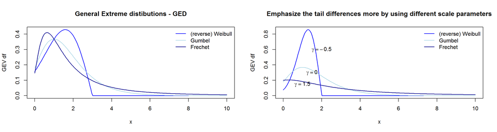

### GPD (Global Pareto Distribution)

Dans l’approche GPD, on va s’intéresser à la distibution des excès, au delà d’un certain seuil, bien choisi.

On a une équivalence entre les approches GPD/GEV. En partant du théorème fondamental, pour un échantillon important, n suffisament grand on a l’approximation suivante: - $F^n(u) \approx exp\{-[1+\gamma(\frac{u-b}{a})]^{-1/\gamma}\}$ avec a>0 et $(b,\gamma) \in \mathbb{R}^2$ En appliquant la transformation n.log à cette expression puis en effectuant un DL de Taylor, on obtient la famille de distributions de Pareto généralisée (GPD) : - $G_{\gamma,\sigma}=1-(1+\gamma\frac{y}{\sigma})^{-1/\gamma}$ pour tout $y \in \mathbb{R}$ tel que $1+\gamma\frac{y}{\sigma}>0$ Le cas $\gamma=0$ est obtenu comme $\displaystyle\lim_{\gamma \to 0}G_{\gamma,\sigma}(y)=G_{0,\sigma}=1+exp(-\frac{y}{\sigma})$

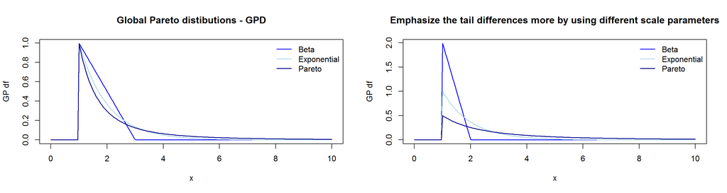

On remarque, que $G_{\gamma,\sigma}(z)=1+log(H_{\gamma}(z))$ avec $b=0$ et $a=\sigma$ La dualité entre les deux approches GEV et GPD montre l’importance particulière du paramètre de forme $\gamma$.

- Si $\gamma<0$ la distribution des excès a une borne supérieure de $\mu - \sigma/\gamma$
- Si $\gamma>0$ la distribution des excès n’a pas de limite supérieure.
- Si $\gamma=0$ la distribution des excès est aussi non bornée.

On rappelle le théorème de Pickands

## Plan et description

On déterminera ensuite la famille la plus appropriée à la série et le domaine d’attraction associé. On terminera notre étude avec une estimation de la probabilité et du niveau de retour. [associé à chacune de ces familles ou distribution de la loi des extrêmes]

# Partie I - Comparaison des approches GEV et GPD sur les données *Marseille*

On s’intéresse dans cette première partie, à la pluviométrie dans la vile de Marseille sur la période allant de 1864 à 1991.

Cette étude est réalisée à patir des données d’accumulations pluviométriques quotidiennes de $10^{-1}$ mm dans la vile de Marseille pendant 127 ans d’observations (1864–1991). La première date est le 1er août 1864. Tous les 29 février ont été supprimés. Pour cet ensemble de données, on va utiliser les deux approches (GEV et GPD) et les comparer.

## Lecture des données - description statistique

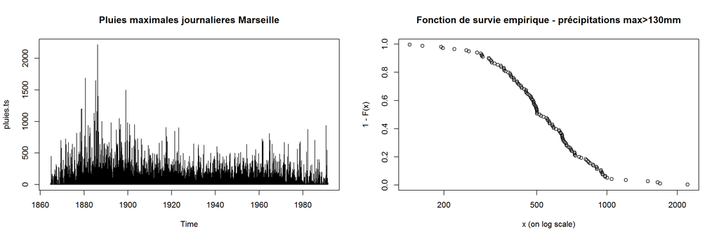

- summary, quantiles, histogramme des précipitations max / an (cf. slides Intro)

```
##    Min. 1st Qu.  Median    Mean 3rd Qu.    Max.
##   143.0   400.0   514.0   594.6   701.0  2215.0
```

```
##   0%  25%  50%  75% 100%
##  143  400  514  701 2215
```

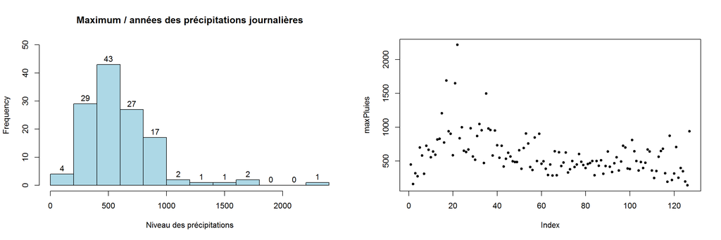

- Comparaison à une loi Log-normale et Gamma

```
## Fitting of the distribution ' lnorm ' by maximum likelihood
## Parameters :
##          estimate Std. Error
## meanlog 6.2808476 0.04067691
## sdlog   0.4584055 0.02876230
## Loglikelihood:  -878.8127   AIC:  1761.625   BIC:  1767.314
## Correlation matrix:
##         meanlog sdlog
## meanlog       1     0
## sdlog         0     1
```

```
## Fitting of the distribution ' gamma ' by maximum likelihood
## Parameters :
##          estimate   Std. Error
## shape 4.833409617 0.5385463678
## rate  0.008126388 0.0009394676
## Loglikelihood:  -882.2411   AIC:  1768.482   BIC:  1774.171
## Correlation matrix:
##           shape      rate
## shape 1.0000000 0.9390625
## rate  0.9390625 1.0000000
```

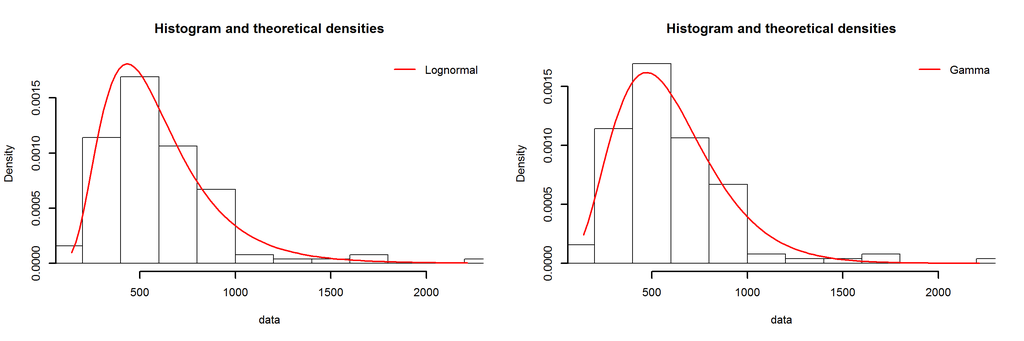

```
## [1] 1934.506
```

```
## [1] 1934.506
```

```
## [1] 1634.576
```

```
## [1] 1634.576
```

```
## [1] 108.3373
```

```
## [1] 2007.549
```

```
##    Min. 1st Qu.  Median    Mean 3rd Qu.    Max.
##   143.0   400.0   514.0   594.6   701.0  2215.0
```

## Choix du niveau des blocs (GEV) et du seuillage (GPD)

- Utilisation de la fonction $blockmaxxer$ du package $extRemes$

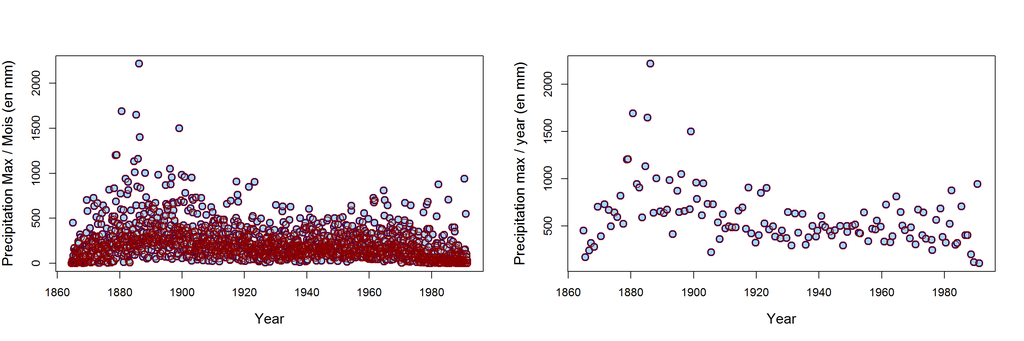

- Ajustement GEV sur les max annuels =>?

```
##
## Call: fgev(x = PluieMatrix)
## Deviance: 1756.301
##
## Estimates
##       loc      scale      shape
## 461.51437  196.76399    0.09805
##
## Standard Errors
##      loc     scale     shape
## 19.49785  14.46937   0.06024
##
## Optimization Information
##   Convergence: successful
##   Function Evaluations: 47
##   Gradient Evaluations: 29
```

- Dans ce qui suit on va utilser la série des max / an construites précedemment.

### Choix du seuil pour l’approche GPD

- function findthresh of the package evir (p38 cours III)

```
## [1] 1690 1009  567
```

```
##  n=10  n=50 n=100
##  1009   686   567
```

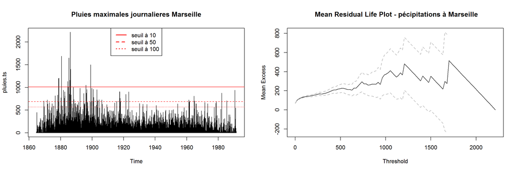

seuil à 600 580 cf p57 cours GPD

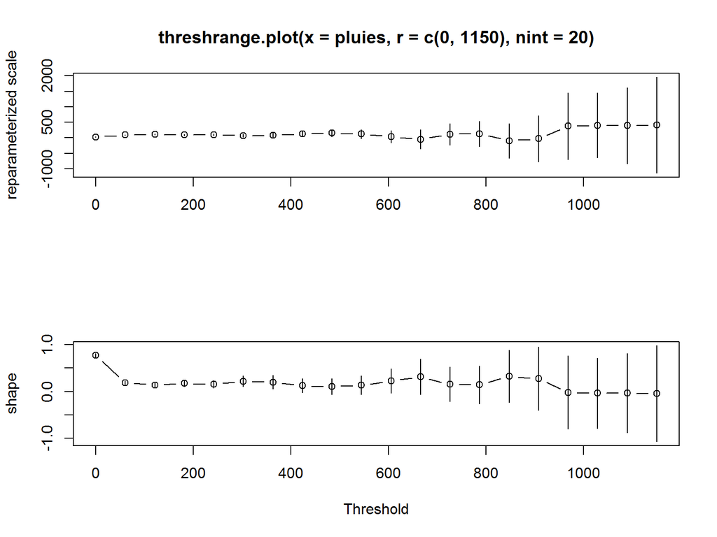

## Estimation des paramètres shape et- scale par MLE et PWM.

### Approche GEV

[output not shown]

- Approximations des paramètres $scale$ et $shape$ et Intervalles de confiance

```
## fevd(x = pluies, type = "GEV", method = "MLE", time.units = "days")
##
## [1] "Normal Approx."
##
##          95% lower CI  Estimate 95% upper CI
## location    0.3288102 0.3288102    0.3288103
## scale       1.8137296 1.8137296    1.8137297
## shape       5.5158527 5.5158528    5.5158528
```

[output not shown]

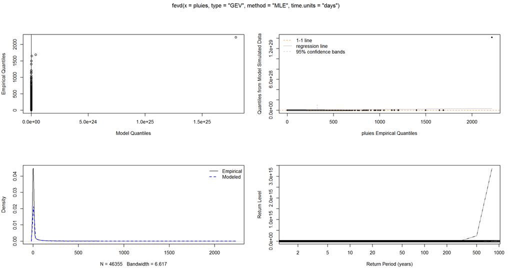

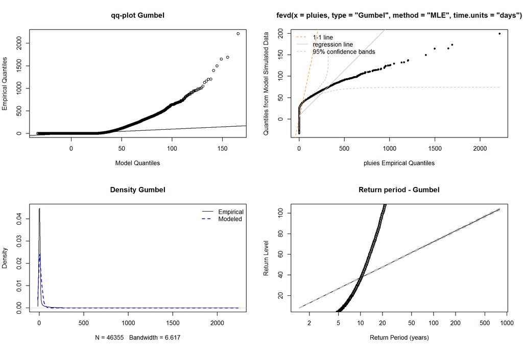

### Approche GPD

- Estimation des paramètres par maximum de vraissamblance dans l’approche GPD (p47 cours GPD)

On utilise la fonction R fved avec 2 la méthode MLE et des moments

| Méthode | scale | shape |
| --- | --- | --- |
| GPD - MLE GV | 165.9205569 | 0.228288 |
| GPD - MLE Exp | 214.9886364 | NA |
| GPD - Moment GV | 165.9205339 | 0.2282358 |

- Approximations des paramètres $scale$ et $shape$ et Intervalles de confiance

```
## fevd(x = pluies, threshold = seuil, type = "GP", method = "MLE",
##     time.units = "days")
##
## [1] "Normal Approx."
##
##       95% lower CI   Estimate 95% upper CI
## scale 111.51172894 165.920557  220.3293848
## shape  -0.03140201   0.228288    0.4879779
```

```
## fevd(x = pluies, threshold = seuil, type = "Exponential", method = "MLE",
##     time.units = "days")
##
## [1] "Normal Approx."
##
## [1] "scale: 214.989"
##
## [1] "95% Confidence Interval: (170.0705, 259.9067)"
```

```
## fevd(x = pluies, threshold = seuil, type = "GP", method = "Lmoments",
##     time.units = "days")
##
## [1] "Parametric Bootstrap"
## 502  iterations
##
##               2.5%    Estimate       97.5%
## scale 115.03853658 165.9205339 232.9638132
## shape  -0.07986034   0.2282358   0.4501449
```

- Graphique - GPD estimé par MLE

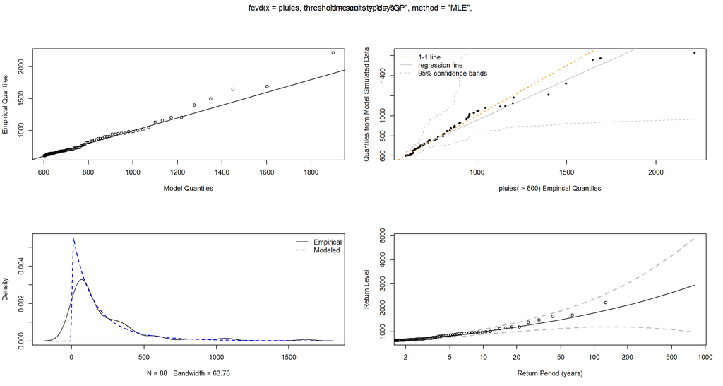

- Graphique - Exponentiel estimé par MLE

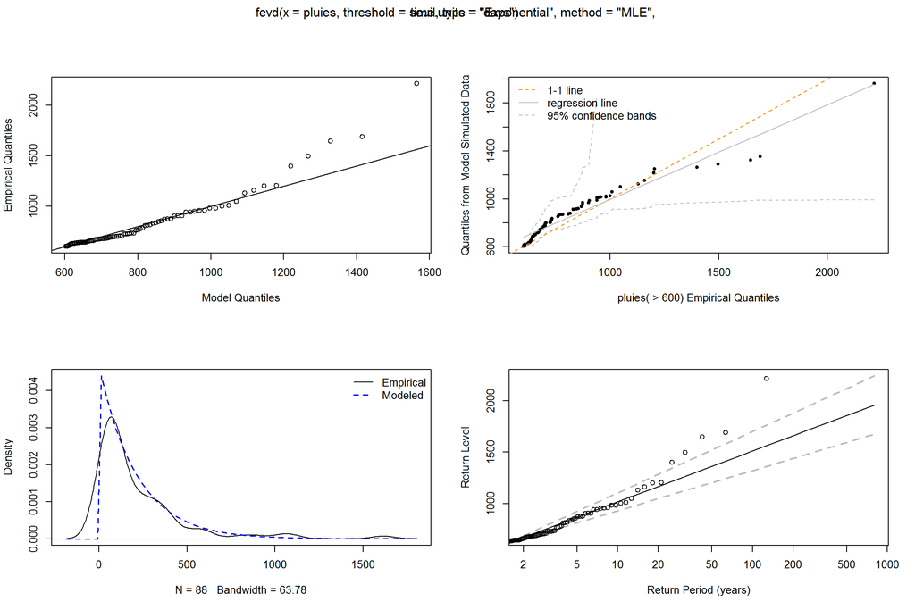

- Graphique - GPD estimé par la PWD

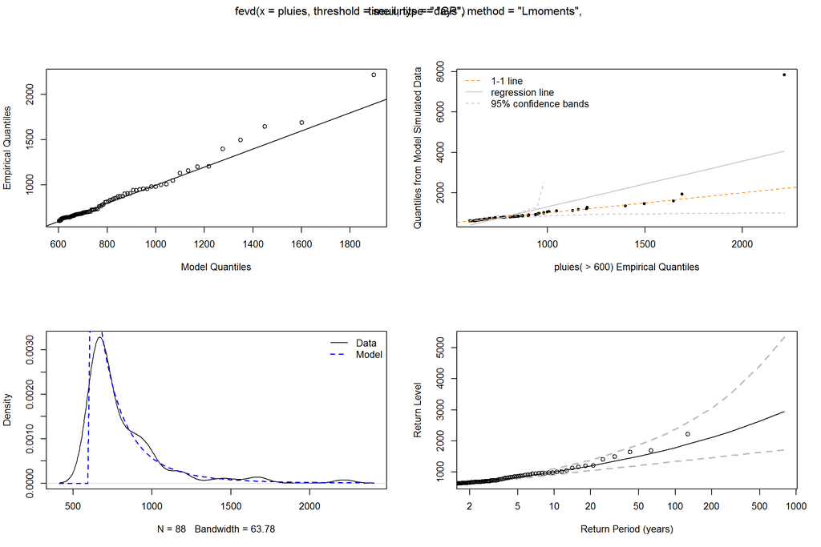

## Domaine d’attraction

- GEV

On étudie le signe de $\gamma$ pour connaître le type de domaine d’attraction: Weibull, Gumbel ou Fréchet.

- Si $\gamma<0$ $F \in MDA(Weibull)$ des short tail distributions.
- Si $\gamma=0$ $F \in MDA(Gumbel)$ des light tail distributions.
- Si $\gamma>0$ $F \in MDA(Fréchet)$ des heavy tail distributions.

On se base sur l’intervalle de confiance de l’estimation de $\gamma$ obtenu précédement

- GPD

## Niveau de retour et interprétation

- GEV
- si $\gamma=0$ le tracé est linéaire
- si $\gamma<0$ le tracé est convexe avec une limite asymptotique : $b-\frac{a}{\gamma}$
- si $\gamma>0$ le tracé est concave et n’a pas de borne finie
- GPD

## Estimation du niveau de retour correspondant à une période 100 ans et 1000 ans

- GEV

| Méthode | 100-year return | IC 95% borne Inf | IC 95% borne Sup |
| --- | --- | --- | --- |
| MLE GEV | 3.440627910^{10} | 3.440627310^{10} | 3.440628510^{10} |
| MLE Gumbel | 72.3568861 | 71.7050733 | 73.0086989 |

| Méthode | 1000-year return | IC 95% borne Inf | IC 95% borne Sup |
| --- | --- | --- | --- |
| MLE GEV | 1.156964310^{16} | 1.15696410^{16} | 1.156964610^{16} |
| MLE Gumbel | 107.397057 | 106.438766 | 108.355348 |

| Méthode | 2-year level | 20-year level | 100-year level | 1000-year level |
| --- | --- | --- | --- | --- |
| MLE GEV | 2.4827974 | 4.286232710^{6} | 3.440627910^{10} | 1.156964310^{16} |
| MLE Gumbel | 8.056698 | 47.6012529 | 72.3568861 | 107.397057 |

- GPD

| Méthode | 100-year return | IC 95% borne Inf | IC 95% borne Sup |
| --- | --- | --- | --- |
| MLE GPD | 1786.085834 | 1199.2759901 | 2372.8956779 |
| MLE Exponentiel | 1511.3378209 | 1320.9298455 | 1701.7457962 |
| Moment GPD | 1785.9337272 | 1350.2838514 | 2449.5121943 |

| Méthode | 1000-year return | IC 95% borne Inf | IC 95% borne Sup |
| --- | --- | --- | --- |
| MLE GPD | 3108.967893 | 904.9970456 | 5312.9387403 |
| MLE Exponentiel | 2006.3674501 | 1712.5317587 | 2300.2031416 |
| Moment GPD | 3108.4367836 | 1670.9925203 | 6378.1645765 |

[output not shown]

# Partie II - Approche *GEV* (Genaral Extreme Distribution) - Données *portpirie*

## Lecture des données - description statistique

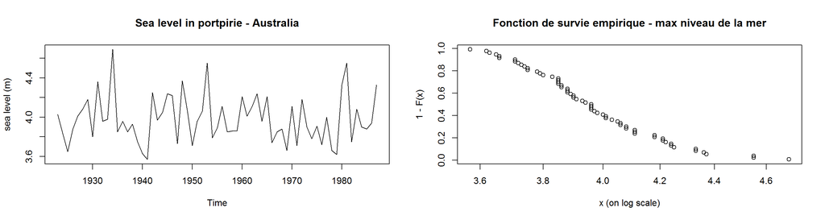

```
##    Min. 1st Qu.  Median    Mean 3rd Qu.    Max.
##   3.570   3.830   3.960   3.981   4.110   4.690
```

```
##   0%  25%  50%  75% 100%
## 3.57 3.83 3.96 4.11 4.69
```

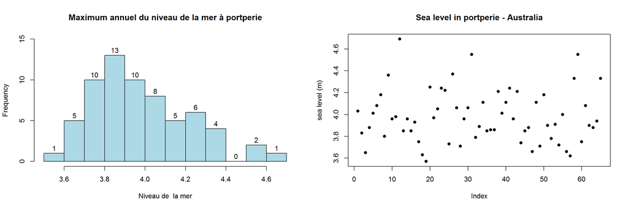

- Comparaison à une loi Log-normale et Gamma

```
## Fitting of the distribution ' lnorm ' by maximum likelihood
## Parameters :
##           estimate  Std. Error
## meanlog 1.37968039 0.007310659
## sdlog   0.05894042 0.005162722
## Loglikelihood:  2.119604   AIC:  -0.2392087   BIC:  4.109566
## Correlation matrix:
##               meanlog         sdlog
## meanlog  1.000000e+00 -1.466606e-14
## sdlog   -1.466606e-14  1.000000e+00
```

```
## Fitting of the distribution ' gamma ' by maximum likelihood
## Parameters :
##        estimate Std. Error
## shape 284.90664   49.94611
## rate   71.57345   12.55834
## Loglikelihood:  1.746143   AIC:  0.5077143   BIC:  4.856489
## Correlation matrix:
##           shape      rate
## shape 1.0000000 0.9991226
## rate  0.9991226 1.0000000
```

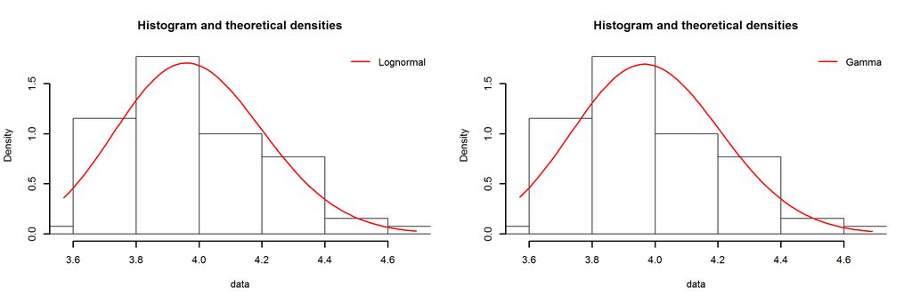

```
## [1] 4.688572
```

```
## [1] 4.688572
```

```
## [1] 4.674685
```

```
## [1] 4.674685
```

```
## [1] 3.236599
```

```
## [1] 4.853634
```

```
##    Min. 1st Qu.  Median    Mean 3rd Qu.    Max.
##   3.570   3.830   3.960   3.981   4.110   4.690
```

## Estimation des paramètres par MLE et PWM.

[output not shown]

- Graphique - Approximation GEV par MLE

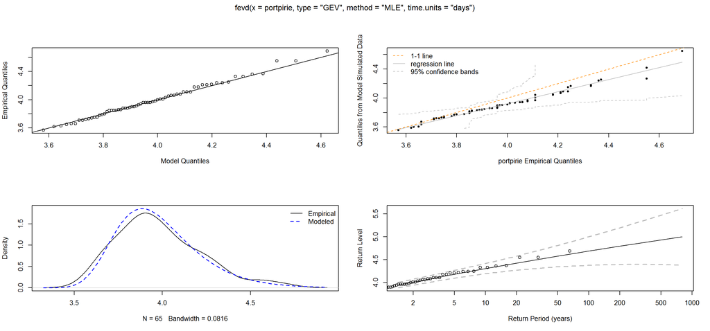

Les graphiques qqplot et qqplot2 montrent une très bonne adéquation des valeurs observées aux valeurs théoriques estimées. Bien qu’ici le gplot2 soit un peu moins bon. La forme de la densité théorique et estimé sont aussi très proches. On en conclu que l’approximation est de bonne qualité.

- Graphique - Approximation Gumble par MLE

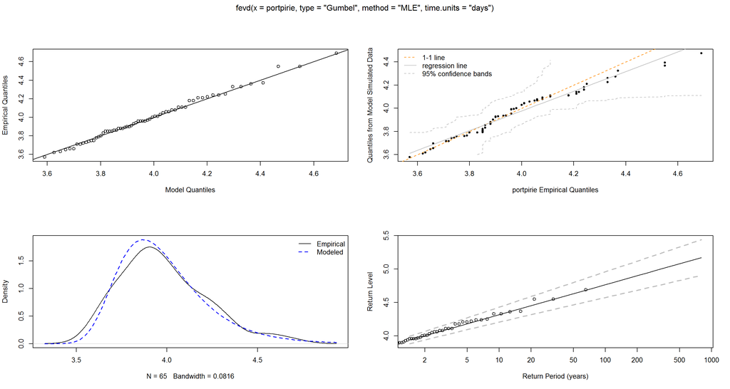

Là aussi les graphiques qqplot et qqplot2 montrent une très bonne adéquation des valeurs observées aux valeurs théoriques estimées. Il en est de même pour la forme de la densité. On en conclu que l’approximation est de bonne qualité.

## Domaine d’attraction

On étudie le signe de $\gamma$ pour connaître le type de domaine d’attraction: Weibull, Gumbel ou Fréchet.

- Approximations des paramètres $scale$ et $shape$ et Intervalles de confiance

```
## fevd(x = portpirie, type = "GEV", method = "MLE", time.units = "days")
##
## [1] "Normal Approx."
##
##          95% lower CI   Estimate 95% upper CI
## location    3.8200037  3.8747499    3.9294960
## scale       0.1583586  0.1980440    0.2377293
## shape      -0.2426841 -0.0501095    0.1424651
```

```
## fevd(x = portpirie, type = "Gumbel", method = "MLE", time.units = "days")
##
## [1] "Normal Approx."
##
##          95% lower CI  Estimate 95% upper CI
## location    3.8194765 3.8694436     3.919411
## scale       0.1579369 0.1948895     0.231842
```

Ici le domaine d’attraction le plus probable semble être de type Gumbel: $\gamma=0$

## Niveau de retour et interprétation

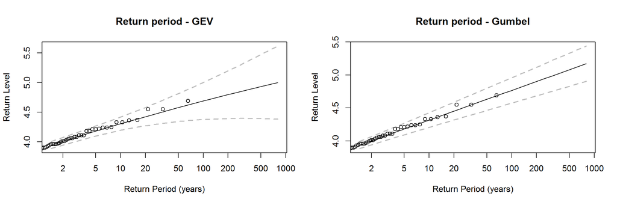

| Méthode | 2-year level | 20-year level | 100-year level | 1000-year level |
| --- | --- | --- | --- | --- |
| MLE GV | 3.946673 | 4.4212978 | 4.6884038 | 5.0310589 |
| MLE Gumbel | 3.9408732 | 4.4483034 | 4.7659643 | 5.2155949 |

## Estimation du niveau de retour correspondant à une période 100 ans et 1000 ans

| Méthode | 100-year return | IC 95% borne Inf | IC 95% borne Sup |
| --- | --- | --- | --- |
| MLE GV | 4.6884038 | 4.3771254 | 4.9996822 |
| MLE Gumbel | 4.7659643 | 4.5741585 | 4.95777 |

| Méthode | 1000-year return | IC 95% borne Inf | IC 95% borne Sup |
| --- | --- | --- | --- |
| MLE GV | 5.0310589 | 4.3764574 | 5.6856604 |
| MLE Gumbel | 5.2155949 | 4.9403707 | 5.490819 |

```
##
## Call: fgev(x = portpirie)
## Deviance: -8.678117
##
## Estimates
##      loc     scale     shape
##  3.87475   0.19805  -0.05012
##
## Standard Errors
##     loc    scale    shape
## 0.02793  0.02025  0.09826
##
## Optimization Information
##   Convergence: successful
##   Function Evaluations: 33
##   Gradient Evaluations: 8
```

```
## [1] "profiling quantile"
```

```
## [1] "profiling quantile"
```

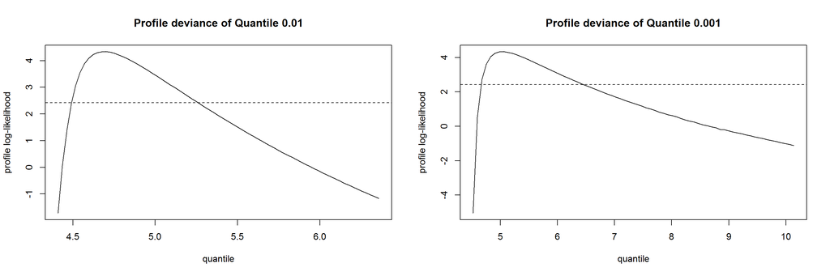

# Partie III - Approche *GPD* (Globale Pareto Distribution) - Données *temps100m*

## Lecture des données - description statistique

Ici on s’intéresse à la loi des miniùuns. Aussi pour étudier la loi des maximum ici on va inverser et regarder les temps en prenant l’opposé.

```
## [1] "numeric"
```

```
##    Min. 1st Qu.  Median    Mean 3rd Qu.    Max.
##  -10.30  -10.26  -10.20  -10.16  -10.07   -9.58
```

```
##       0%      25%      50%      75%     100%
## -10.3049 -10.2610 -10.1955 -10.0715  -9.5800
```

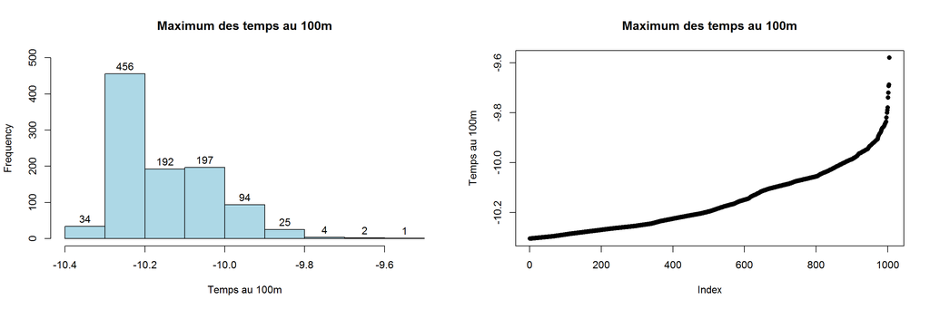

## Choix du niveau de seuillage

- function findthresh of the package evir (p38 cours III)

```
## [1] -9.6875 -9.8387 -9.9827
```

```
##    n=10    n=50   n=100
## -9.8387 -9.9281 -9.9827
```

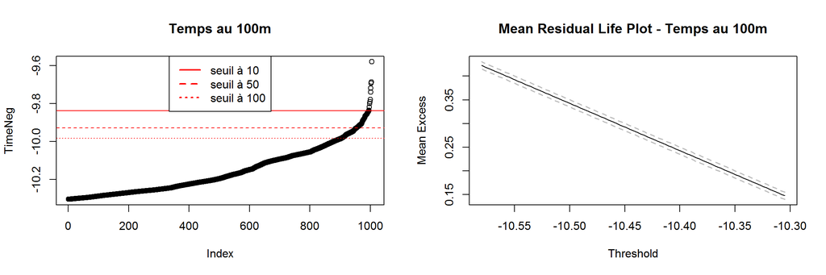

- A partir des graphes tcplot: partie constante du graphe.

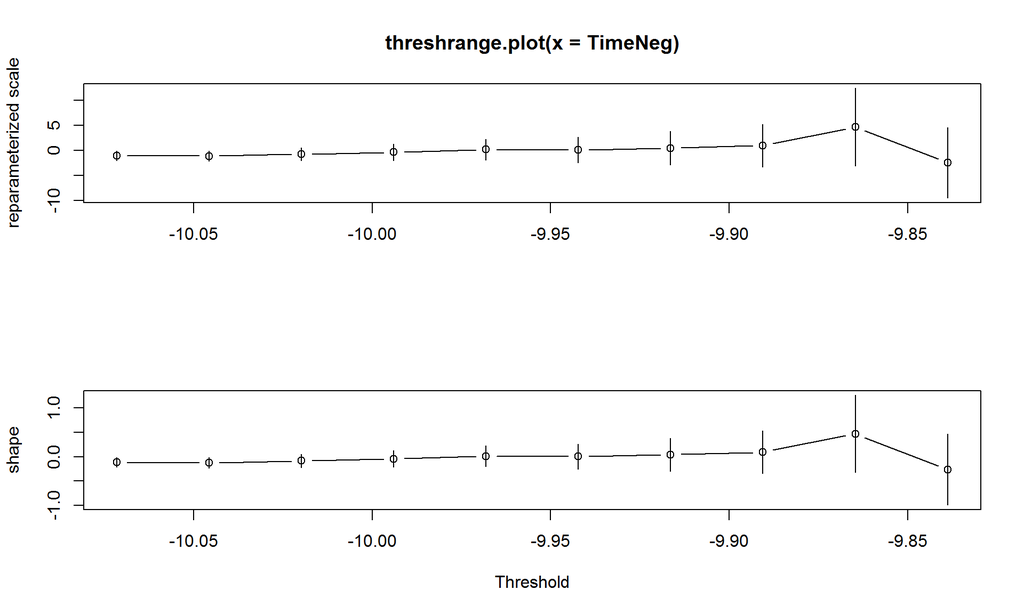

On obtient un seuil paproximatif de -9.92

## Estimation des paramètres par MLE et PWM.

On utilise la fonction R fved avec 2 la méthode MLE et des moments

| Méthode | scale | shape |
| --- | --- | --- |
| MLE GPD | 0.0673474 | 0.0281371 |
| MLE Exponentiel | 0.0692932 | NA |
| Moment GPD | 0.0650986 | 0.0605335 |

- Graphique - GPD estimé par MLE

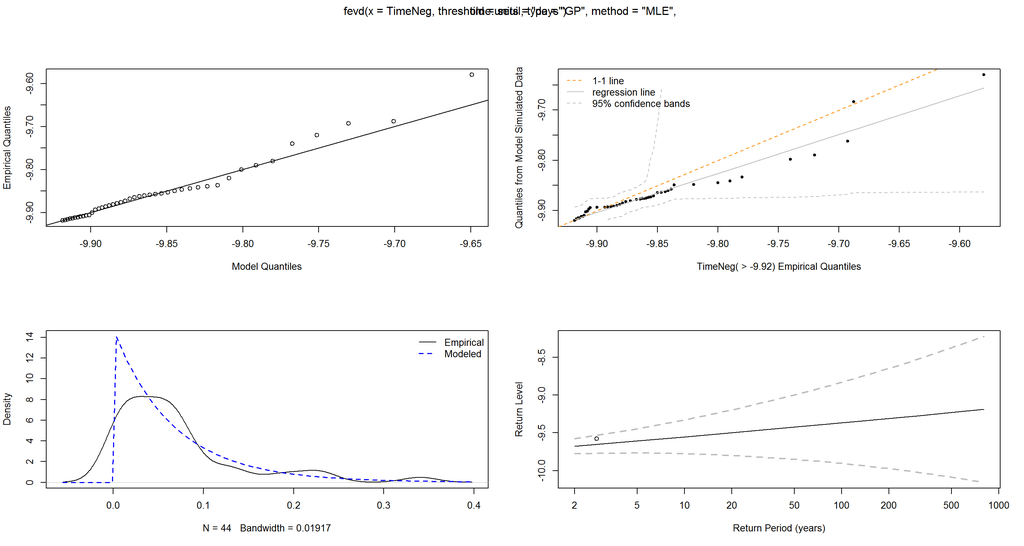

- Graphique - Exponentiel estimé par MLE

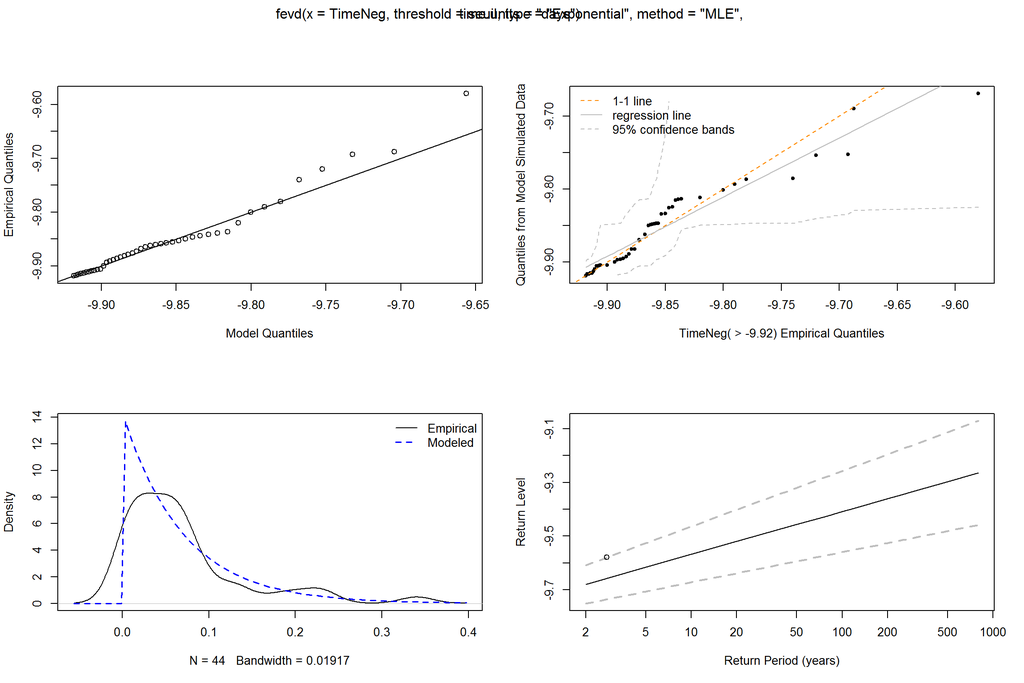

- Graphique - GPD estimé par les moments

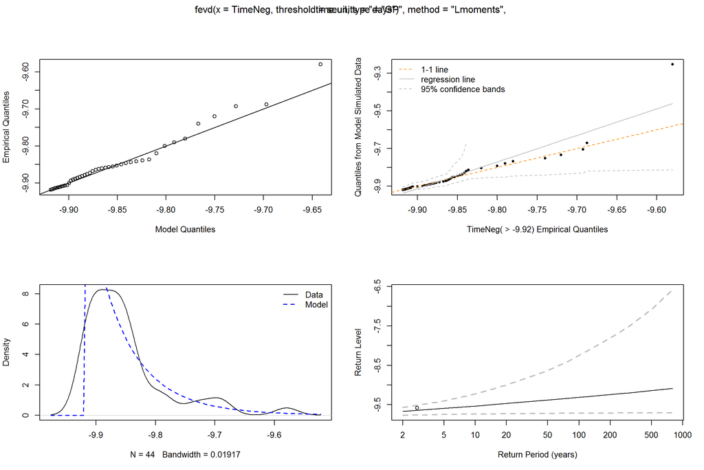

## Domaine d’attraction

- Approximations des paramètres $scale$ et $shape$ et Intervalles de confiance

```
## fevd(x = TimeNeg, threshold = seuil, type = "GP", method = "MLE",
##     time.units = "days")
##
## [1] "Normal Approx."
##
##       95% lower CI   Estimate 95% upper CI
## scale   0.03782059 0.06734740    0.0968742
## shape  -0.29624524 0.02813714    0.3525195
```

```
## fevd(x = TimeNeg, threshold = seuil, type = "Exponential", method = "MLE",
##     time.units = "days")
##
## [1] "Normal Approx."
##
## [1] "scale: 0.069"
##
## [1] "95% Confidence Interval: (0.0488, 0.0898)"
```

```
## fevd(x = TimeNeg, threshold = seuil, type = "GP", method = "Lmoments",
##     time.units = "days")
##
## [1] "Parametric Bootstrap"
## 502  iterations
##
##              2.5%   Estimate     97.5%
## scale  0.04139038 0.06509862 0.1047092
## shape -0.36194206 0.06053348 0.3306191
```

## Niveau de retour et interprétation

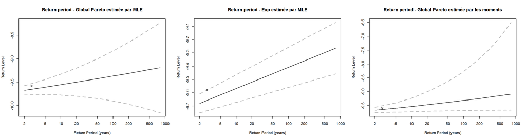

[output not shown]

## Estimation du niveau de retour correspondant à une période 100 ans et 1000 ans

| Méthode | 100-year return | IC 95% borne Inf | IC 95% borne Sup |
| --- | --- | --- | --- |
| MLE GPD | -9.3678391 | -9.9037681 | -8.8319101 |
| MLE Exponentiel | -9.4088104 | -9.5597601 | -9.2578607 |
| Moment GPD | -9.3146077 | -9.6936759 | -8.1100029 |

| Méthode | 1000-year return | IC 95% borne Inf | IC 95% borne Sup |
| --- | --- | --- | --- |
| MLE GPD | -9.1706745 | -10.1891766 | -8.1521724 |
| MLE Exponentiel | -9.249257 | -9.4473214 | -9.0511925 |
| Moment GPD | -9.0632179 | -9.6595199 | -6.4521126 |